# D209 P.A. : — NVM2 TASK 2: PREDICTIVE ANALYSIS

[Link to the Panopto Video](https://wgu.hosted.panopto.com/Panopto/Pages/Viewer.aspx?id=a69fca93-6d95-470c-aa1e-ad2800c1af3b)

https://wgu.hosted.panopto.com/Panopto/Pages/Viewer.aspx?id=a69fca93-6d95-470c-aa1e-ad2800c1af3b

###### -------------------------------------------------------------------------------------------------------------------------------------------------------------------------------------------------------

### Exploring the Data

#### Importing Libraries:

```python
#imporing the needed libraries.
import pandas as pd
pd.set_option('display.max_rows', None)
pd.set_option('display.max_columns', None) #modified Pandas options to fully display the large dataset when needed
## !!! Trying to Display a full Dataframe may cause a problem.
import numpy as np
np.set_printoptions(precision=5, suppress=True)
import matplotlib.pyplot as plt
from sklearn.tree import plot_tree
import seaborn as sns

import sklearn
from sklearn.tree import DecisionTreeRegressor
from sklearn.model_selection import GridSearchCV
from sklearn.metrics import mean_squared_error, r2_score
import scipy.stats as stats
```

```python
#Reading the Data file (As received) churn_clean.csv
df_raw= pd.read_csv('churn_clean.csv')
target='MonthlyCharge'
df_raw.head()
```

|  | CaseOrder | Customer_id | Interaction | UID | City | State | County | Zip | Lat | Lng | Population | Area | TimeZone | Job | Children | Age | Income | Marital | Gender | Churn | Outage_sec_perweek | Email | Contacts | Yearly_equip_failure | Techie | Contract | Port_modem | Tablet | InternetService | … |
| --- | --- | --- | --- | --- | --- | --- | --- | --- | --- | --- | --- | --- | --- | --- | --- | --- | --- | --- | --- | --- | --- | --- | --- | --- | --- | --- | --- | --- | --- | --- |
| 0 | 1 | K409198 | aa90260b-4141-4a24-8e36-b04ce1f4f77b | e885b299883d4f9fb18e39c75155d990 | Point Baker | AK | Prince of Wales-Hyder | 99927 | 56.25100 | -133.37571 | 38 | Urban | America/Sitka | Environmental health practitioner | 0 | 68 | 28561.99 | Widowed | Male | No | 7.978323 | 10 | 0 | 1 | No | One year | Yes | Yes | Fiber Optic | … |
| 1 | 2 | S120509 | fb76459f-c047-4a9d-8af9-e0f7d4ac2524 | f2de8bef964785f41a2959829830fb8a | West Branch | MI | Ogemaw | 48661 | 44.32893 | -84.24080 | 10446 | Urban | America/Detroit | Programmer, multimedia | 1 | 27 | 21704.77 | Married | Female | Yes | 11.699080 | 12 | 0 | 1 | Yes | Month-to-month | No | Yes | Fiber Optic | … |
| 2 | 3 | K191035 | 344d114c-3736-4be5-98f7-c72c281e2d35 | f1784cfa9f6d92ae816197eb175d3c71 | Yamhill | OR | Yamhill | 97148 | 45.35589 | -123.24657 | 3735 | Urban | America/Los_Angeles | Chief Financial Officer | 4 | 50 | 9609.57 | Widowed | Female | No | 10.752800 | 9 | 0 | 1 | Yes | Two Year | Yes | No | DSL | … |
| 3 | 4 | D90850 | abfa2b40-2d43-4994-b15a-989b8c79e311 | dc8a365077241bb5cd5ccd305136b05e | Del Mar | CA | San Diego | 92014 | 32.96687 | -117.24798 | 13863 | Suburban | America/Los_Angeles | Solicitor | 1 | 48 | 18925.23 | Married | Male | No | 14.913540 | 15 | 2 | 0 | Yes | Two Year | No | No | DSL | … |
| 4 | 5 | K662701 | 68a861fd-0d20-4e51-a587-8a90407ee574 | aabb64a116e83fdc4befc1fbab1663f9 | Needville | TX | Fort Bend | 77461 | 29.38012 | -95.80673 | 11352 | Suburban | America/Chicago | Medical illustrator | 0 | 83 | 40074.19 | Separated | Male | Yes | 8.147417 | 16 | 2 | 1 | No | Month-to-month | Yes | No | Fiber Optic | … |

#### Data info:

```python
df_raw.info() #Data Information of the Raw DataFrame (As received)
```

```
<class 'pandas.core.frame.DataFrame'>
RangeIndex: 10000 entries, 0 to 9999
Data columns (total 50 columns):
 #   Column                Non-Null Count  Dtype
---  ------                --------------  -----
 0   CaseOrder             10000 non-null  int64
 1   Customer_id           10000 non-null  object
 2   Interaction           10000 non-null  object
 3   UID                   10000 non-null  object
 4   City                  10000 non-null  object
 5   State                 10000 non-null  object
 6   County                10000 non-null  object
 7   Zip                   10000 non-null  int64
 8   Lat                   10000 non-null  float64
 9   Lng                   10000 non-null  float64
```

[output cut: 42 more lines]

```python
raw_variables=['CaseOrder', 'Customer_id', 'Interaction', 'UID', 'City', 'State',
               'County', 'Zip', 'Lat', 'Lng', 'Population', 'Area', 'TimeZone', 'Job',
               'Children', 'Age', 'Income', 'Marital', 'Gender', 'Churn',
               'Outage_sec_perweek', 'Email', 'Contacts', 'Yearly_equip_failure',
               'Techie', 'Contract', 'Port_modem', 'Tablet', 'InternetService',
               'Phone', 'Multiple', 'OnlineSecurity', 'OnlineBackup',
               'DeviceProtection', 'TechSupport', 'StreamingTV', 'StreamingMovies',
               'PaperlessBilling', 'PaymentMethod', 'Tenure', 'MonthlyCharge',
               'Bandwidth_GB_Year', 'Item1', 'Item2', 'Item3', 'Item4', 'Item5',
               'Item6', 'Item7', 'Item8']

num_variables = ['CaseOrder', 'Zip', 'Lat', 'Lng', 'Population', 'Children',
                 'Age','Income', 'Outage_sec_perweek', 'Email', 'Contacts',
                 'Yearly_equip_failure', 'Tenure', 'MonthlyCharge', 'Bandwidth_GB_Year',
                 'Item1', 'Item2', 'Item3', 'Item4', 'Item5', 'Item6', 'Item7', 'Item8']

categ_variables = ['Customer_id', 'Interaction', 'UID', 'City', 'State', 'County', 'Area',
                   'TimeZone', 'Job', 'Marital', 'Gender', 'Churn', 'Techie', 'Contract',
                   'Port_modem', 'Tablet', 'InternetService', 'Phone', 'Multiple',
                   'OnlineSecurity', 'OnlineBackup', 'DeviceProtection', 'TechSupport',
                   'StreamingTV', 'StreamingMovies', 'PaperlessBilling', 'PaymentMethod']

print('raw_variables:',len(raw_variables),'  num_variables:',len(num_variables),'  cat_variables:',len(categ_variables))
```

```
raw_variables: 50   num_variables: 23   cat_variables: 27
```

### Summary statistics:

```python
#Summary statistics of Numerical variables of the Raw DataFrame
df_raw.describe().T  #Transposed to show large number of variables displayed as rows
```

|  | count | mean | std | min | 25% | 50% | 75% | max |
| --- | --- | --- | --- | --- | --- | --- | --- | --- |
| CaseOrder | 10000.0 | 5000.500000 | 2886.895680 | 1.000000 | 2500.750000 | 5000.500000 | 7500.250000 | 10000.000000 |
| Zip | 10000.0 | 49153.319600 | 27532.196108 | 601.000000 | 26292.500000 | 48869.500000 | 71866.500000 | 99929.000000 |
| Lat | 10000.0 | 38.757567 | 5.437389 | 17.966120 | 35.341828 | 39.395800 | 42.106908 | 70.640660 |
| Lng | 10000.0 | -90.782536 | 15.156142 | -171.688150 | -97.082813 | -87.918800 | -80.088745 | -65.667850 |
| Population | 10000.0 | 9756.562400 | 14432.698671 | 0.000000 | 738.000000 | 2910.500000 | 13168.000000 | 111850.000000 |
| Children | 10000.0 | 2.087700 | 2.147200 | 0.000000 | 0.000000 | 1.000000 | 3.000000 | 10.000000 |
| Age | 10000.0 | 53.078400 | 20.698882 | 18.000000 | 35.000000 | 53.000000 | 71.000000 | 89.000000 |
| Income | 10000.0 | 39806.926771 | 28199.916702 | 348.670000 | 19224.717500 | 33170.605000 | 53246.170000 | 258900.700000 |
| Outage_sec_perweek | 10000.0 | 10.001848 | 2.976019 | 0.099747 | 8.018214 | 10.018560 | 11.969485 | 21.207230 |
| Email | 10000.0 | 12.016000 | 3.025898 | 1.000000 | 10.000000 | 12.000000 | 14.000000 | 23.000000 |
| Contacts | 10000.0 | 0.994200 | 0.988466 | 0.000000 | 0.000000 | 1.000000 | 2.000000 | 7.000000 |
| Yearly_equip_failure | 10000.0 | 0.398000 | 0.635953 | 0.000000 | 0.000000 | 0.000000 | 1.000000 | 6.000000 |
| Tenure | 10000.0 | 34.526188 | 26.443063 | 1.000259 | 7.917694 | 35.430507 | 61.479795 | 71.999280 |
| MonthlyCharge | 10000.0 | 172.624816 | 42.943094 | 79.978860 | 139.979239 | 167.484700 | 200.734725 | 290.160419 |
| Bandwidth_GB_Year | 10000.0 | 3392.341550 | 2185.294852 | 155.506715 | 1236.470827 | 3279.536903 | 5586.141369 | 7158.981530 |
| Item1 | 10000.0 | 3.490800 | 1.037797 | 1.000000 | 3.000000 | 3.000000 | 4.000000 | 7.000000 |
| Item2 | 10000.0 | 3.505100 | 1.034641 | 1.000000 | 3.000000 | 4.000000 | 4.000000 | 7.000000 |
| Item3 | 10000.0 | 3.487000 | 1.027977 | 1.000000 | 3.000000 | 3.000000 | 4.000000 | 8.000000 |
| Item4 | 10000.0 | 3.497500 | 1.025816 | 1.000000 | 3.000000 | 3.000000 | 4.000000 | 7.000000 |
| Item5 | 10000.0 | 3.492900 | 1.024819 | 1.000000 | 3.000000 | 3.000000 | 4.000000 | 7.000000 |
| Item6 | 10000.0 | 3.497300 | 1.033586 | 1.000000 | 3.000000 | 3.000000 | 4.000000 | 8.000000 |
| Item7 | 10000.0 | 3.509500 | 1.028502 | 1.000000 | 3.000000 | 4.000000 | 4.000000 | 7.000000 |
| Item8 | 10000.0 | 3.495600 | 1.028633 | 1.000000 | 3.000000 | 3.000000 | 4.000000 | 8.000000 |

#### Data visualization:

*Function plt_summary() to inspect the data visually usind Histogram, Boxplot and scattered plots. The following function is defined to visually identify statistical parameters and to get the sense from the Data, such as identify the outliers , ranges, dominant values,.etc

```python
'''Custom function to inspect the data visually using Histogram/Bar, Boxplot and scattered plots
this function takes 3 parameters, 1st is DataFrame , 2nd is the preferable plot ("hist" , "box" , " scat" , "target_scat" or "target_histplot" )
The target argument will be used only in the case of target vs variables scat plots, and will not be used for other options
For Histograms with non-numeric columns , the function will use Bar charts (in Green color) instead of Histogram
"scat": plotting scatterd plot against the 1st column of the D.F.
"target_scat": plotting scatterd plot of num. variables against a 'target' column of the D.F.
"target_histplot":plotting histplot of numeric or countplot of cat. variables against the target' column
'''

def plt_summary(df_1,plt_type,target):
    numerics = ['uint8','uint16','uint32','int16', 'int32', 'int64', 'float16', 'float32', 'float64']

    if plt_type =='target_histplot':
        pltlist=df_1.columns
#         for number,cols in enumerate(df_1.columns):
#             if (len(df_1[cols].value_counts())>=20):
#                 pltlist.remove(cols)
        print("Number of columns:  "+str(len(pltlist))) #Printing the number of columns.

    elif plt_type =='hist':
        pltlist=df_1.columns
        print("Number of columns:  "+str(df_1.shape[1])) #Printing the number of columns.

    else :
        df_n = df_1.select_dtypes(include=numerics).copy()   # selecting only the numeric columns as it's suitable for mentioned plots
        pltlist=df_n.columns
        print("Number of Numeric columns:  "+str(df_n.shape[1])) #Printing the number of numeric columns.


    plt.style.use('default')
    plt.figure(figsize=(15,30))
    plt_rows = 11
    plt_cols = 5

    for n, col in enumerate(pltlist):   #enumerating each column of the data, starting from index
        b=n+1
        ax=plt.subplot2grid(shape=(plt_rows,plt_cols),loc=((int(np.ceil(b/plt_cols)-1)),((b-1)%plt_cols)))
        if plt_type == 'hist':
            if df_1[col].dtype in numerics:
                ax.hist(df_1.loc[:,col],bins = 50)  #plotting Histogram
                ax.set_title(str(col)+' (*num)')
            else:
                if len(df_1[col].value_counts())>2000:
                    ax.set_title(str(col)+' ('+str(len(df_1[col].value_counts()))+' unq val.)')
                    continue
                df_1.groupby(col).size().plot.bar(rot=0,color='g') #plotting Bar chart
                ax.set_title(str(col)+' (*categ. '+str(len(df_1[col].value_counts()))+' cat.)')
                if len(df_1[col].value_counts())>20:
                    ax.tick_params(bottom=False,labelbottom=False)

        elif plt_type == 'box':
            msk = ~np.isnan(df_n.loc[:,col])
            ax.boxplot(df_n.loc[msk,col])  #plotting Box plot (used a mask to filter the null values)
            #ax.boxplot(df.loc[:,col])
            ax.set_title(col)
        elif plt_type == 'scat':
            ax.scatter(df_n.iloc[:,0],df_n.loc[:,col],s=0.1,alpha=0.1) #plotting scatterd plot against the index of the D.F.
            ax.set_title(col)

        elif plt_type == 'target_scat':
            ax.scatter(df_n.loc[:,col],df_n.loc[:,target],s=1,alpha=0.1,color='b') #plotting scatterd plot of num. variables against the 'target' column of the D.F.
            #ax.set_title(col)
            ax.set_xlabel(col)

        elif plt_type == 'target_hexbin':
            ax = df_n.plot.hexbin(ax=ax,x=col, y=target,gridsize=50, sharex=False) #plotting hexbin plot
            ax.set_title(col)

        elif (plt_type == 'target_histplot'):
            if (df_1[target].dtype not in numerics):
                ax.set_title(str(col)+' (*categ. '+str(len(df_1[col].value_counts()))+' cat.)')
                if (len(df_1[col].value_counts())<=700):
                    sns.countplot(ax=ax, data = df_1,x = col,hue = target,alpha=0.7) #plotting countplot of cat. variables against the 'target' column
                    if len(df_1[col].value_counts())>20:
                        ax.tick_params(bottom=False,labelbottom=False)
                elif (df_1[col].dtype in numerics):
                        sns.histplot(df_1, x=col, hue=target, element="poly",ax=ax) #plotting histplot of num. variables against the 'target' column
                        ax.set_title(str(col)+' (*num)')
#                         ax.plt.legend(fontsize='xx-small', title_fontsize='xx-small')
#                         plt.setp(ax.get_legend().get_texts(), fontsize='5') # for legend text
#                         plt.setp(ax.get_legend().get_title(), fontsize='32') # for legend title
            elif df_1[target].dtype in numerics:
                if (df_1[col].dtype not in numerics):
                    ax.set_title(str(col)+' (*categ. '+str(len(df_1[col].value_counts()))+' cat.)')
                    if (len(df_1[col].value_counts())<=5):
                        sns.histplot(df_1, x=target, hue=col, element="poly",ax=ax) #plotting histplot of num. variables against the 'target' column
                elif (df_1[col].dtype in numerics):
                    ax = df_1.plot.hexbin(ax=ax,x=target, y=col,gridsize=30, sharex=False, cmap="cubehelix_r") #plotting hexbin plot
#                     continue



    plt.tight_layout()
    plt.show()

    return
```

```
Number of columns:  50
```

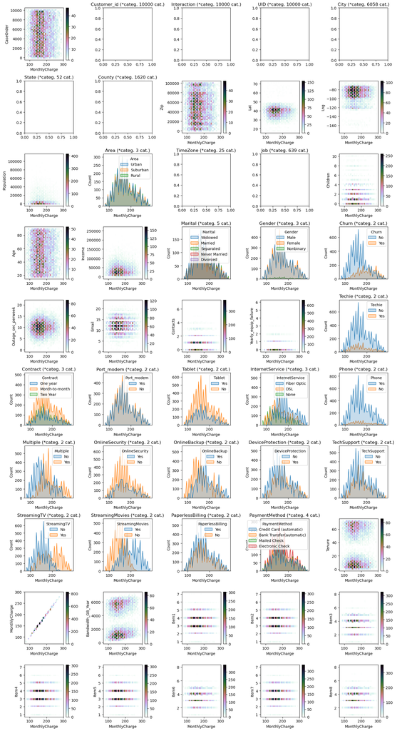

```
Wall time: 20 s
```

```python
%%time
#calling the plt_summary to the Raw DataFrame
plt_summary(df_raw,"target_histplot",target)
```

##### Part I: Research Question

##### A. Describe the purpose of this data mining report by doing the following:

##### 1. Propose one question relevant to a real-world organizational situation that you will answer using one of the following prediction methods:

• decision trees

• random forests

• advanced regression (i.e., lasso or ridge regression)

The customer's 'MonthlyCharge' supposed to be one of the most important features to any company, probably the company's profit depends on increasing the Monthly Charge of all customers, I think it can be considered the second most important variable included in the Churn data set (coming after the 'Churn' variable), and specifically the first most important continuous variable.

DecesionTree regression will be used to check the factors and features that affect the MonthlyCharge and the significance of each of them.

##### 2. Define one goal of the data analysis. Ensure that your goal is reasonable within the scope of the scenario and is represented in the available data.

Obviously, the monthly charge of each customer depends the most on the number and types of services provided, but some of them may be more important than others. and more significant than others. the objective of the data analysis is to identify the features and to test their inter relationships in order to build a DecesionTree regression prediction model that can be used to predict the monthly charge of each customer based on available features or criteria. thus giving the stake holders the insight to know and to support the main factors that may affect the monthly charge , and probably the company's profit.

###### -------------------------------------------------------------------------------------------------------------------------------------------------------------------------------------------------------

##### Part II: Method Justification

##### B. Explain the reasons for your chosen prediction method from part A1 by doing the following:

##### 1. Explain how the prediction method you chose analyzes the selected data set. Include expected outcomes.

A decision tree is arriving at an estimate by asking a series of questions to the data, each question narrowing our possible values until the model get confident enough to make a single prediction. The order of the question as well as their content are being determined by the model. In addition, the questions asked are all in a True/False form. For each True and False answer there are separate branches. No matter the answers to the questions, we eventually reach a prediction (leaf node). Start at the root node at the top and progress through the tree answering the questions along the way. As a supervised machine learning model, a decision tree learns to map data to outputs in what is called the training phase of model building.

Decision Trees follow Sum of Product (SOP) representation. The Sum of product (SOP) is also known as Disjunctive Normal Form. For a class, every branch from the root of the tree to a leaf node having the same class is conjunction (product) of values, different branches ending in that class form a disjunction (sum). The primary challenge in the decision tree implementation is to identify which attributes do we need to consider as the root node and each level. Handling this is to know as the attributes selection. We have different attributes selection measures to identify the attribute which can be considered as the root note at each level.

During training, the model is fitted with any historical data that is relevant to the problem domain and the true value we want the model to learn to predict. The model learns any relationships between the data and the target variable. After the training phase, the decision tree produces a tree calculating the best questions as well as their order to ask in order to make the most accurate estimates possible.

https://gdcoder.com/decision-tree-regressor-explained-in-depth/

https://www.kdnuggets.com/2020/01/decision-tree-algorithm-explained.html

##### 2. Summarize one assumption of the chosen prediction method.

Decision tree is considered to be a non-parametric method. This means that decision trees have no assumptions about the space distribution and the classifier structure

https://gdcoder.com/decision-tree-regressor-explained-in-depth/

But overall , there are some assumptions while creating Decision Tree:

- In the beginning, the whole training set is considered as the root.
- Feature values are preferred to be categorical. If the values are continuous then they are discretized prior to building the model, as the recursive splitting or branching is based on binary decesions.
- Records are distributed recursively on the basis of attribute values.
- Order to placing attributes as root or internal node of the tree is done by using some statistical approach.

https://www.kdnuggets.com/2020/01/decision-tree-algorithm-explained.html

##### 3. List the packages or libraries you have chosen for Python or R, and justify how each item on the list supports the analysis.

Selected Python, the general-purpose, interpreted, object-oriented language, which supports many useful packages for creating linear models Selected Python libraries such as:

- Pandas : For data manipulation and analysis.
- numpy : The core of every analytical solution in the Python language. It provides the user with multidimensional arrays, along with a large set of functions to operate multiple mathematical operations on these arrays.
- Matplotlib: for visualization
- Scikit-learn: Offers the functions for data preprocessing, supervised and unsupervised learning, model selection, validation, and error metrics.
- scipy.stats: for checking the prediction errors normality.

from Scikit-learn library set of functions were imported and used such as:

- DecisionTreeRegressor : the class of Decision Tree Regression
- GridSearchCV : for choosing best hyper parameters
- mean_squared_error : as regression error metric

###### -------------------------------------------------------------------------------------------------------------------------------------------------------------------------------------------------------

##### Part III: Data Preparation

##### C. Perform data preparation for the chosen data set by doing the following:

##### 1. Describe one data preprocessing goal relevant to the prediction method from part A1.

Given that the data provided is clean , with no missing data and the data can be considered balanced (from data exploration steps) , the DecisionTreeRegressor algorism needed minimum data preparations such as:

- Dropping the irrelevant features (the insignificant variables).
- Getting the categorical features as dummy variables for utilizing the categorical variables,to use only the most relevant component out of them.

##### 2. Identify the initial data set variables that you will use to perform the analysis for the prediction question from part A1, and group each variable as continuous or categorical.

An initial Decesion tree model has been used to select the important variables, those selected variables are the most significant features for the analysis.

##### Initial model

```python
#Dropping irrelevant columns (shouldn't have any relationship with the target)
df_ed=df_raw.copy()
drop_cols = ['CaseOrder','Customer_id','UID','Interaction' ] #,'City','State','County','Zip','Lng','Lat','Population','Area','TimeZone','Job'
df_ed.drop(columns=drop_cols,inplace=True)
```

```python
# Preaparing inputs of model
X_init=df_ed.copy()
X_init=X_init.drop([target],axis=1) #dropping te target column from the predictors data set
y=df_ed[target] # assigning the target to vector y
```

```python
# Adding dummy variables
dummy_cols = [dummy for dummy in categ_variables if dummy in X_init.columns]
X_init=pd.get_dummies(X_init,drop_first=True,columns=dummy_cols)
```

Note: The number of features has exploded after converting categorical variables into dummy variables

```python
X_init.info()
```

```
<class 'pandas.core.frame.DataFrame'>
RangeIndex: 10000 entries, 0 to 9999
Columns: 8438 entries, Zip to PaymentMethod_Mailed Check
dtypes: float64(6), int64(15), uint8(8417)
memory usage: 81.9 MB
```

```python
# Splitting the data into train and test portions
X_train, X_test, y_train, y_test = sklearn.model_selection.train_test_split(X_init, y, test_size = 0.30)
```

```python
init_model=DecisionTreeRegressor()
init_model.fit(X_train, y_train)
```

```
DecisionTreeRegressor()
```

```python
print(init_model.score(X_test, y_test))
print(mean_squared_error(y_test, init_model.predict(X_test)))
```

```
0.9999818346078272
0.03380730206724301
```

Finding the important features :

|  | Feature | Importance |
| --- | --- | --- |
| 8433 | StreamingMovies_Yes | 3.646629e-01 |
| 8432 | StreamingTV_Yes | 2.878917e-01 |
| 8427 | Multiple_Yes | 1.457210e-01 |
| 8424 | InternetService_Fiber Optic | 7.999165e-02 |
| 8429 | OnlineBackup_Yes | 6.831073e-02 |
| 8430 | DeviceProtection_Yes | 2.143929e-02 |
| 8431 | TechSupport_Yes | 1.980423e-02 |
| 8425 | InternetService_None | 1.140998e-02 |
| 8428 | OnlineSecurity_Yes | 7.668438e-04 |
| 3 | Population | 8.452678e-07 |
| 17 | Item5 | 8.068321e-07 |
| 12 | Bandwidth_GB_Year | 1.079357e-14 |
| 11 | Tenure | 1.071222e-14 |
| 7 | Outage_sec_perweek | 3.975448e-15 |
| 6 | Income | 3.109033e-15 |
| 0 | Zip | 2.904085e-15 |
| 5 | Age | 2.690152e-15 |
| 1 | Lat | 2.557858e-15 |
| 19 | Item7 | 2.458957e-15 |
| 8 | Email | 1.890025e-15 |
| 4 | Children | 1.563749e-15 |
| 8418 | Churn_Yes | 1.533753e-15 |
| 2 | Lng | 1.398630e-15 |
| 9 | Contacts | 1.268883e-15 |
| 18 | Item6 | 1.150315e-15 |
| 13 | Item1 | 9.802435e-16 |
| 8436 | PaymentMethod_Electronic Check | 8.841717e-16 |
| 15 | Item3 | 8.544588e-16 |
| 8434 | PaperlessBilling_Yes | 7.327773e-16 |
| 8423 | Tablet_Yes | 6.420822e-16 |

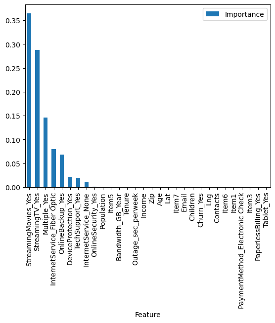

```python
feature_importance=pd.DataFrame({"Feature":X_init.columns,'Importance':init_model.feature_importances_})
feature_importance.sort_values(by='Importance',ascending=False)[:30].plot.bar('Feature',rot=90)
feature_importance.sort_values(by='Importance',ascending=False)[:30]
```

Only 8 features are the most significant for the purpose of the analysis, all of them are Categorical.

```python
important_features =(feature_importance.sort_values(by='Importance',ascending=False)[:8].Feature)
print(important_features)
X=X_init[important_features]
```

```
8433            StreamingMovies_Yes
8432                StreamingTV_Yes
8427                   Multiple_Yes
8424    InternetService_Fiber Optic
8429               OnlineBackup_Yes
8430           DeviceProtection_Yes
8431                TechSupport_Yes
8425           InternetService_None
Name: Feature, dtype: object
```

##### 3. Explain the steps used to prepare the data for the analysis. Identify the code segment for each step.

- Explained.

##### 4. Provide a copy of the cleaned data set.

```python
# Saving a copy of the prepared data set.
D209_t2_input=X.copy()
D209_t2_input['data-MontlyCharge']=y
D209_t2_input.to_csv('D209_t2_model_input.csv', index = False)
```

###### -------------------------------------------------------------------------------------------------------------------------------------------------------------------------------------------------------

##### Part IV: Analysis

##### D. Perform the data analysis and report on the results by doing the following:

##### 1. Split the data into training and test data sets and provide the file(s).

```python
# Splitting the data into train and test portions
X_train, X_test, y_train, y_test = sklearn.model_selection.train_test_split(X, y, test_size = 0.30)
```

```python
# Saving a copy of the splitted data sets.
D209_t2_train=X_train.copy()
D209_t2_train['data-MontlyCharge']=y_train
D209_t2_train.to_csv('D209_t2_model_train.csv', index = True)

D209_t2_test=X_test.copy()
D209_t2_test['data-MontlyCharge']=y_test
D209_t2_test.to_csv('D209_t2_model_test.csv', index = True)
```

##### 2. Describe the analysis technique you used to appropriately analyze the data. Include screenshots of the intermediate calculations you performed.

Predicting the target variable using Decision tree regression:

1- preparing the input data by Dropping the irrelevant features (the insignificant variables). and Getting the categorical features as dummy variables for utilizing the categorical variables,to use only the most relevant component out of them.

2- splitting the input data into a training set (70%) and a testing set(30%)

3- initializing a model as a DecisionTreeRegressor object of sklearn library.

4- fitting the model using the training data set.

5- testing the model to predicting the target values of the testing data set and calculating the error.

6- estimating model best hyperparameters using grid search and cross validation to avoid overfitting.

##### 3. Provide the code used to perform the prediction analysis from part D2.

optimizing alpha through cross validation and grid search

```python
%%time
reg = DecisionTreeRegressor()
hp = {"ccp_alpha":np.arange(0,0.3,0.05),"min_samples_leaf":np.arange(0,50,5)} #,
for cv in [3,4,5,10]:
    grid=GridSearchCV(reg,
                      param_grid=hp,
                      cv=10,
                      #scoring=mean_squared_error(y_valid, grid.predict(X_valid)),
                      n_jobs=-1)
    grid.fit(X_train,y_train)
    mse_value = mean_squared_error(y_test, grid.best_estimator_.predict(X_test))
    print('fold ',cv,' ',grid.best_params_,'score: ', grid.best_score_,'mse_value:' , mse_value)
```

```
fold  3   {'ccp_alpha': 0.0, 'min_samples_leaf': 5} score:  0.9991861487304133 mse_value: 1.521946468023007
fold  4   {'ccp_alpha': 0.0, 'min_samples_leaf': 5} score:  0.9991861487304133 mse_value: 1.5219464680230086
fold  5   {'ccp_alpha': 0.0, 'min_samples_leaf': 5} score:  0.9991861487304133 mse_value: 1.5219464680230086
fold  10   {'ccp_alpha': 0.0, 'min_samples_leaf': 5} score:  0.9991861487304133 mse_value: 1.5219464680230066
Wall time: 17.4 s
```

Error investigation :

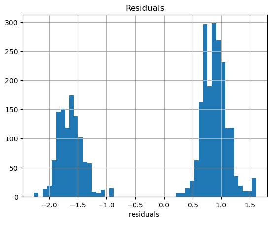

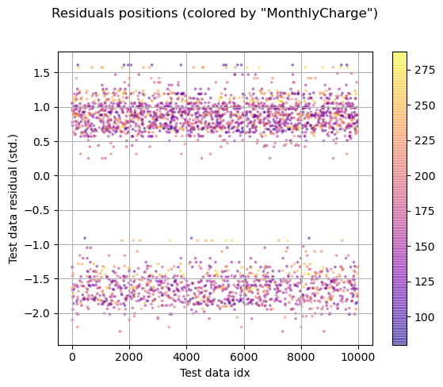

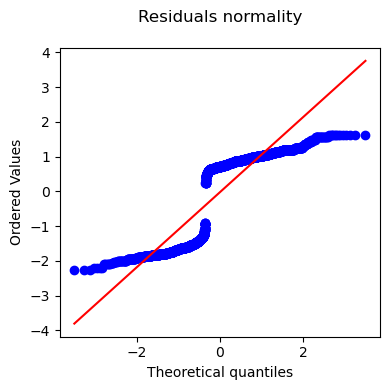

```python
tst=grid.best_estimator_
residuals =tst.predict(X_test)-y_test
# MLR examination plots
residuals.hist(bins = 50)
plt.title('Residuals')
plt.xlabel('residuals \n\n')
plt.show()

plt.scatter(pd.DataFrame(X_test).index,residuals,s=3,alpha=0.4,c=y_test,cmap='plasma')
plt.title('Residuals positions (colored by "'+ target+'")\n\n');plt.xlabel('Test data idx');plt.ylabel('Test data residual (std.)')
plt.colorbar();plt.grid('on')
plt.show()

# QQ-Plot
fig, ax = plt.subplots(figsize=(4, 4))
stats.probplot(residuals, plot=ax) # QQ-Plot
plt.title('Residuals normality\n')
plt.tight_layout()
plt.show()
```

###### -------------------------------------------------------------------------------------------------------------------------------------------------------------------------------------------------------

##### Part V: Data Summary and Implications

##### E. Summarize your data analysis by doing the following:

##### 1. Explain the accuracy and the mean squared error (MSE) of your prediction model.

```python
# applied to test data
accuracy = r2_score(y_test, grid.best_estimator_.predict(X_test))
mse_value = mean_squared_error(y_test, grid.best_estimator_.predict(X_test))
print('accuracy score (R2): ',accuracy,'MSE_value:' , mse_value)
```

```
accuracy score (R2):  0.9991816829171427 MSE_value: 1.5219464680230066
```

Very high prediction accuracy and very low MSE

```python
plt.style.use('default')
plt.figure(figsize=(300,8))
destrplot=plot_tree(grid.best_estimator_,feature_names = X.columns,filled = True)
```

[figure not shown]

##### 2. Discuss the results and implications of your prediction analysis.

- All variables are practically meaningful as all of them represents services and it's relevant to estimate the MonthlyCharge based on these services.
- the residuals are centred around zero, even though they take the form of bands due to the nature of the dependant variable.
- Overfitting is not a problem in this model, for the mentioned reason, the prediction can follow simple arithmetics if we have the accurate services fees.
- The risiduals of the the prediction (errors) are distributed around zero but none of the values is accurately zero , this can be due to that the target variable isn't perfectly continuous (blocked or finely descretized).

##### 3. Discuss one limitation of your data analysis.

- the model has a very high R2 , probably because the MonthlyCharge is determined directly as the summation of the payment for these services.
- The grid search estimating the best hyperparameters showed a strong tendency to overfitting, the best alpha is zero and the min_samples_leaf is very low, the cross-validation revealed that the relationship between the input variables and the target variable is (almost) perfectly linear.
- The very low number of samples at the leaves is very risky, for increasing the chance of overfitting, but it is relevant to the problem (predicting Monthly charge) for the reasons discussed earlier.
- Some observations have been artificially created according to the (D207 D208 D209 Churn Data Consideration and Dictionary.pdf), meaning the presence of some bias in estimation specifically for the "brand new customers" (Heteroscedasticity).

##### 4. Recommend a course of action for the real-world organizational situation from part A1 based on your results and implications discussed in part E2.

- Based on the final model features, some services are significantly contributing to the value of the MonthlyCharge such as StreamingTV and StreamingMovies, these services should get marketed and sold more to increase the company revenue.

###### -------------------------------------------------------------------------------------------------------------------------------------------------------------------------------------------------------

##### Part VI: Demonstration

##### F. Provide a Panopto video recording that includes a demonstration of the functionality of the code used for the analysis and a summary of the programming environment.

[Link to the Panopto Video](https://wgu.hosted.panopto.com/Panopto/Pages/Viewer.aspx?id=a69fca93-6d95-470c-aa1e-ad2800c1af3b)

https://wgu.hosted.panopto.com/Panopto/Pages/Viewer.aspx?id=a69fca93-6d95-470c-aa1e-ad2800c1af3b

##### G. Record the web sources used to acquire data or segments of third-party code to support the analysis. Ensure the web sources are reliable.

##### H. Acknowledge sources, using in-text citations and references, for content that is quoted, paraphrased, or summarized.

##### I. Demonstrate professional communication in the content and presentation of your submission.

##### References:

(datacamp) Data Mining I – D209 course materials and Labs https://learn.datacamp.com/custom-tracks/custom-data-mining-i

https://www.kdnuggets.com/2020/01/decision-tree-algorithm-explained.html

https://gdcoder.com/decision-tree-regressor-explained-in-depth/

https://www.udemy.com/course/python-for-data-science-machine-learning/

https://www.udemy.com/course/data-science-bootcamp-with-python/

Scikit-learn Crash Course - Machine Learning Library for Python https://www.youtube.com/watch?v=0B5eIE_1vpU

General Questions/Answers from https://stackoverflow.com/

Documentation of Python packages: pandas, matplotlib,numpy,sklearn and scipy